# Supplementary Information: Models

Laura Geronimo

## 0.1 Full Sample: Variable Selection Procedure

### 0.1.2 SVSS test

Running SVSS test to see which variables are included

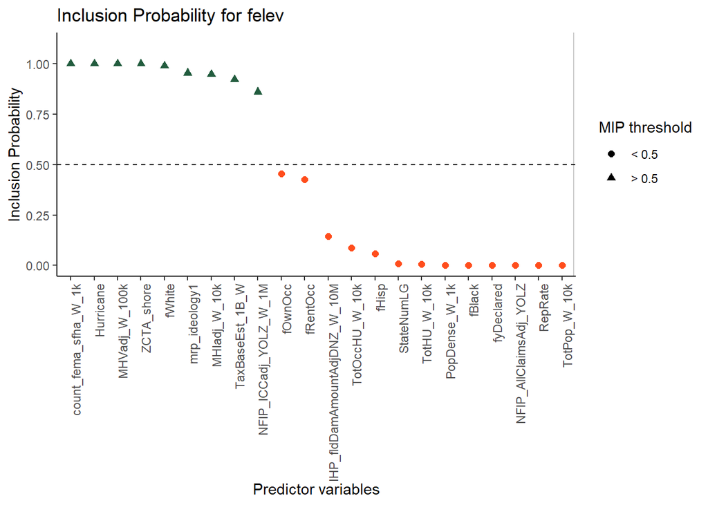

### 0.1.3 Correlation Matrices on select vars

Note that in preparation for modeling, we examine all of the variables recommended in the SVSS test, plus variables that were significant in the Chi-Square and Anova tests, and are relevant to the literature based on domain knowledge.

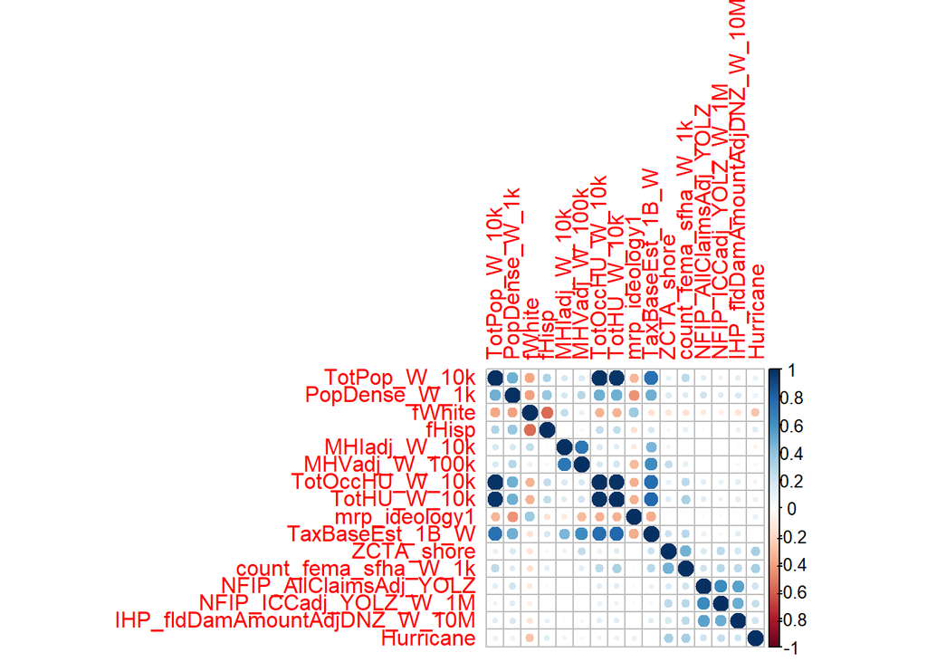

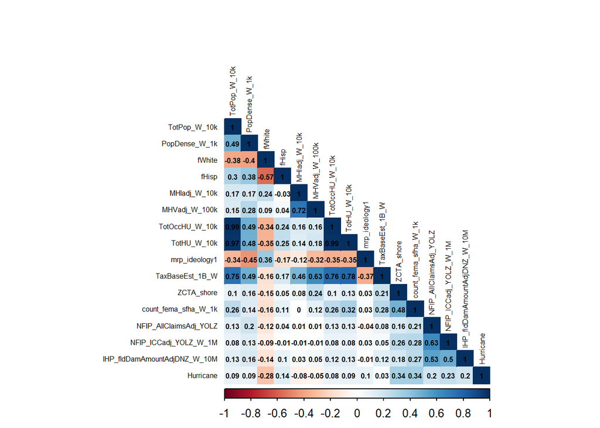

Given the high correlation between MHV and MHI, we drop MHI.

Some notes: -MRP ideology is negatively corrleated with PopDense (urban areas more liberal) -MPR ideology is negatively correlated with MHV: as MHV increase, republican ideology decreases (suggests lower-income is correlated with republicanism) -Tax base and MHV are positively correlated -FWhite and MPR ideology are positively correlated

## 0.2 Model 1: All hypotheses

##### 0.2.0.0.1 Correlation Matrices for M1

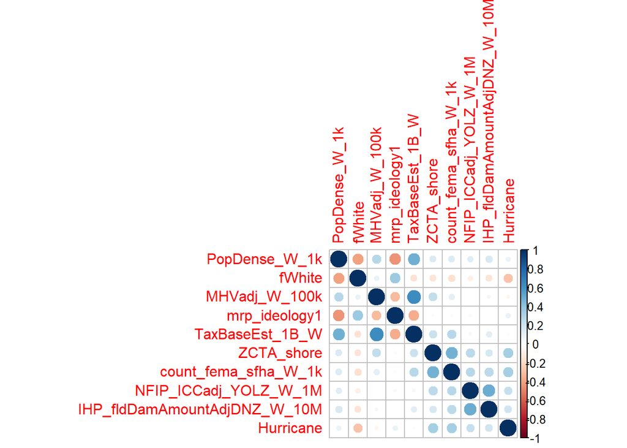

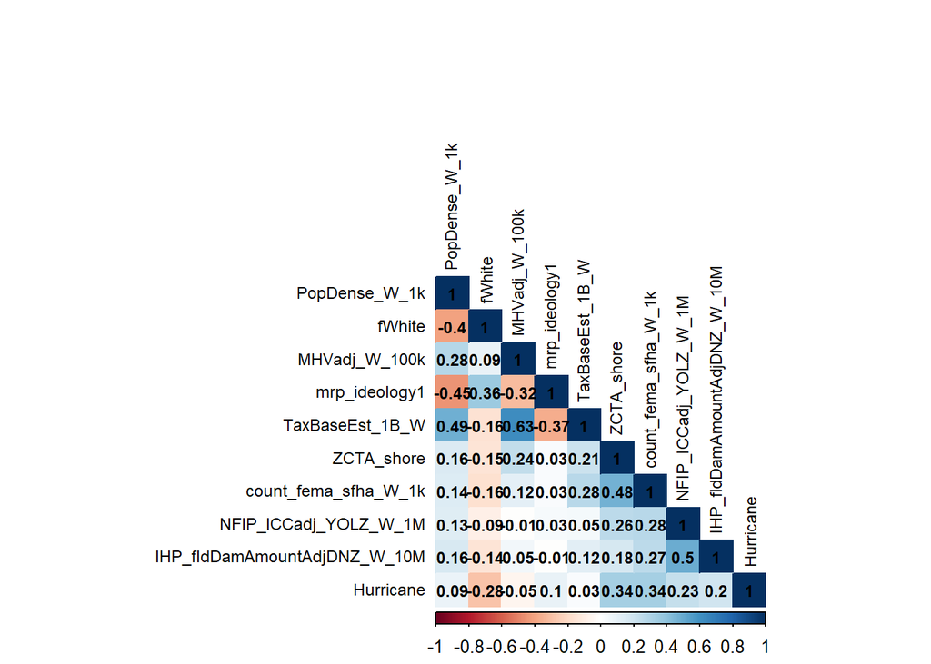

Based on analysis of the correlation matrix, we retain all variables except the Tax Base (corr > 0.5 with MHV). Next we run a model without Fixed effects and check the VIF scores. We include an interaction term on MHV and fWhite

##### 0.2.0.0.3 M1 - Full model with fixed effects & select vars

The stepwise procedure identifies a model that includes 6 variables, and interaction term, and fixed effects.

Note that the stepwise model drops variables of interest like political ideology.

##### 0.2.0.0.4 M1_SW: M1 stepwise model & diagnostics

**Logit Model 1B: Full sample (testing Race and MHV**

|  | *Dependent variable:* |
| --- | --- |
|  | odds Ratio of felev |
| MHV (100k W) | 0.83 |
|  | (0.19) |
| Fraction White | 1.04 |
|  | (0.39) |
| Shoreline ZCTA | 4.71*** |
|  | (0.11) |
| Count of HUs in FEMA SFHA 1k (W) | 1.19*** |
|  | (0.03) |
| NFIP ICC Claims 1M (W) by ZCTA-YOL | 1.48*** |
|  | (0.12) |
| Population Density 1k (W) | 0.95 |
|  | (0.03) |
| MHV:Fraction White interaction | 1.59** |
|  | (0.22) |
| Constant | 0.00 |
|  | (3,503.48) |
| State FE | YES |
| Year FE | YES |
| Pseudo R2 | 0.47 |
| Observations | 5,658 |
| Log Likelihood | -1,617.96 |
| Akaike Inf. Crit. | 3,413.92 |
| *Note:* | p<0.1; p<0.05; p<0.01 |

##### 0.2.0.0.5 M1 Series A.0: Single variable model with FE for all explanatory vars:

**Logit Model Comparison: Single Variable Mode**

|  | *Dependent variable:* |  |  |  |  |  |  |  |
| --- | --- | --- | --- | --- | --- | --- | --- | --- |
|  | odds Ratio of felev |  |  |  |  |  |  |  |
|  | (1) | (2) | (3) | (4) | (5) | (6) | (7) | (8) |
| MHV (100k W) |  | 1.43*** |  |  |  |  |  | 0.94 |
|  |  | (0.04) |  |  |  |  |  | (0.17) |
| Fraction White |  |  | 3.53*** |  |  |  |  | 1.30 |
|  |  |  | (0.21) |  |  |  |  | (0.36) |
| Shoreline ZCTA |  |  |  | 6.45*** |  |  |  |  |
|  |  |  |  | (0.10) |  |  |  |  |
| Count of HUs in FEMA SFHA 1k (W) |  |  |  |  | 1.42*** |  |  |  |
|  |  |  |  |  | (0.03) |  |  |  |
| NFIP ICC Claims 1M (W) by ZCTA-YOL |  |  |  |  |  | 2.32*** |  |  |
|  |  |  |  |  |  | (0.12) |  |  |
| Population Density 1k (W) |  |  |  |  |  |  | 1.00 |  |
|  |  |  |  |  |  |  | (0.03) |  |
| MHV:Fraction White interaction |  |  |  |  |  |  |  | 1.61** |
|  |  |  |  |  |  |  |  | (0.20) |
| Constant | 0.00 | 0.00 | 0.00 | 0.00 | 0.00 | 0.00 | 0.00 | 0.00 |
|  | (3,454.33) | (3,425.01) | (3,426.37) | (3,526.15) | (3,481.96) | (3,460.65) | (3,454.32) | (3,406.73) |
| State FE | YES | YES | YES | YES | YES | YES | YES |  |
| Year FE | YES | YES | YES | YES | YES | YES | YES |  |
| Pseudo R2 | 0.38 | 0.4 | 0.39 | 0.45 | 0.42 | 0.39 | 0.38 | 0.4 |
| Observations | 5,658 | 5,658 | 5,658 | 5,658 | 5,658 | 5,658 | 5,658 | 5,658 |
| Log Likelihood | -1,876.06 | -1,839.69 | -1,857.04 | -1,672.39 | -1,779.95 | -1,846.44 | -1,876.07 | -1,826.82 |
| Akaike Inf. Crit. | 3,916.13 | 3,845.38 | 3,880.09 | 3,510.78 | 3,725.89 | 3,858.87 | 3,918.13 | 3,823.64 |
| *Note:* | p<0.1; p<0.05; p<0.01 |  |  |  |  |  |  |  |

##### 0.2.0.0.6 M1 Series A.1 (Starting with best model from above and dropping vars)

**Logit Model Comparison: Full Sample, Dropping variables**

|  | *Dependent variable:* |  |  |  |  |  |  |  |
| --- | --- | --- | --- | --- | --- | --- | --- | --- |
|  | Odds Ratio of felev |  |  |  |  |  |  |  |
|  | (1) | (2) | (3) | (4) | (5) | (6) | (7) | (8) |
| MHV (100k W) | 0.83 | 0.83 | 0.83 | 1.23*** | 0.90 | 0.84 | 0.84 | 0.76 |
|  | (0.19) | (0.19) | (0.19) | (0.05) | (0.19) | (0.19) | (0.19) | (0.18) |
| Fraction White | 1.04 | 1.04 | 1.04 | 1.91** | 1.13 | 1.14 | 1.08 | 1.11 |
|  | (0.39) | (0.39) | (0.39) | (0.27) | (0.37) | (0.39) | (0.39) | (0.39) |
| Shoreline ZCTA | 4.71*** | 4.71*** | 4.71*** | 4.71*** |  | 5.58*** | 4.89*** | 4.68*** |
|  | (0.11) | (0.11) | (0.11) | (0.11) |  | (0.10) | (0.11) | (0.11) |
| Count of HUs in FEMA SFHA 1k (W) | 1.19*** | 1.19*** | 1.19*** | 1.19*** | 1.35*** |  | 1.21*** | 1.19*** |
|  | (0.03) | (0.03) | (0.03) | (0.03) | (0.03) |  | (0.03) | (0.03) |
| NFIP ICC Claims 1M (W) by ZCTA-YOL | 1.48*** | 1.48*** | 1.48*** | 1.47*** | 1.78*** | 1.67*** |  | 1.45*** |
|  | (0.12) | (0.12) | (0.12) | (0.12) | (0.12) | (0.12) |  | (0.12) |
| Population Density 1k (W) | 0.95 | 0.95 | 0.95 | 0.93** | 0.96 | 0.96 | 0.96 |  |
|  | (0.03) | (0.03) | (0.03) | (0.03) | (0.03) | (0.03) | (0.03) |  |
| MHV:Fraction White interaction | 1.59** |  | 1.59** |  | 1.58** | 1.60** | 1.57** | 1.73** |
|  | (0.22) |  | (0.22) |  | (0.22) | (0.22) | (0.22) | (0.21) |
| fWhite:MHVadj_W_100k |  | 1.59** |  |  |  |  |  |  |
|  |  | (0.22) |  |  |  |  |  |  |
| Constant | 0.00 | 0.00 | 0.00 | 0.00 | 0.00 | 0.00 | 0.00 | 0.00 |
|  | (3,503.48) | (3,503.48) | (3,503.48) | (3,506.25) | (3,444.68) | (3,494.64) | (3,503.04) | (3,500.16) |
| State FE | YES | YES | YES | YES | YES | YES | YES | YES |
| Year FE | YES | YES | YES | YES | YES | YES | YES | YES |
| Pseudo R2 | 0.47 | 0.47 | 0.47 | 0.47 | 0.43 | 0.46 | 0.47 | 0.47 |
| Observations | 5,658 | 5,658 | 5,658 | 5,658 | 5,658 | 5,658 | 5,658 | 5,658 |
| Log Likelihood | -1,617.96 | -1,617.96 | -1,617.96 | -1,619.73 | -1,734.58 | -1,637.74 | -1,623.99 | -1,619.10 |
| Akaike Inf. Crit. | 3,413.92 | 3,413.92 | 3,413.92 | 3,415.46 | 3,645.17 | 3,451.49 | 3,423.98 | 3,414.20 |
| *Note:* | p<0.1; p<0.05; p<0.01 |  |  |  |  |  |  |  |

The model above confirms that the stepwise process selected the model with the lowest AIC

##### 0.2.0.0.7 Post Tests M1

##### 0.2.0.0.8 Examining outliers and leverage points

###### 0.2.0.0.8.1 Diagnostics:

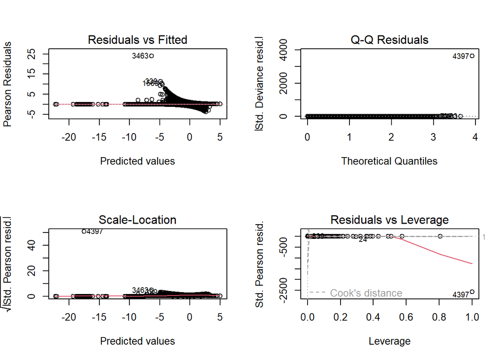

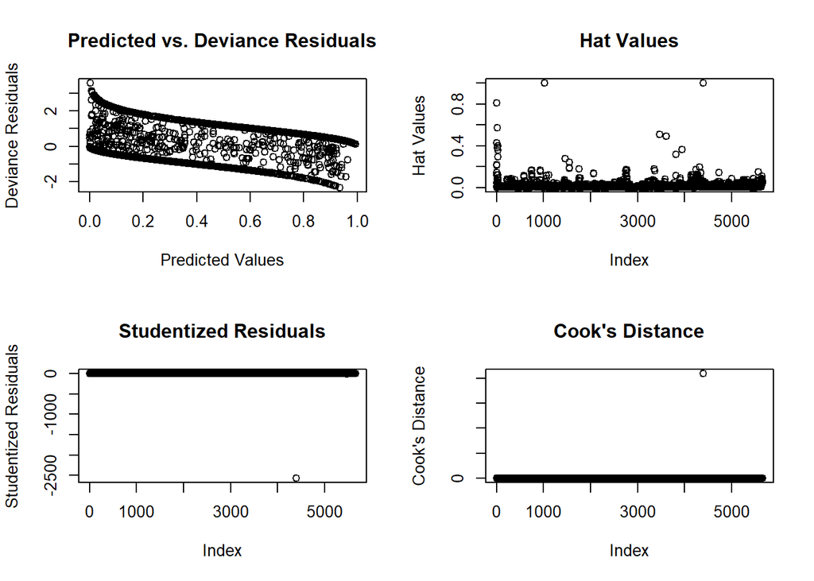

```
##       rstudent unadjusted p-value Bonferroni p
## 4397 -2572.152                  0            0
```

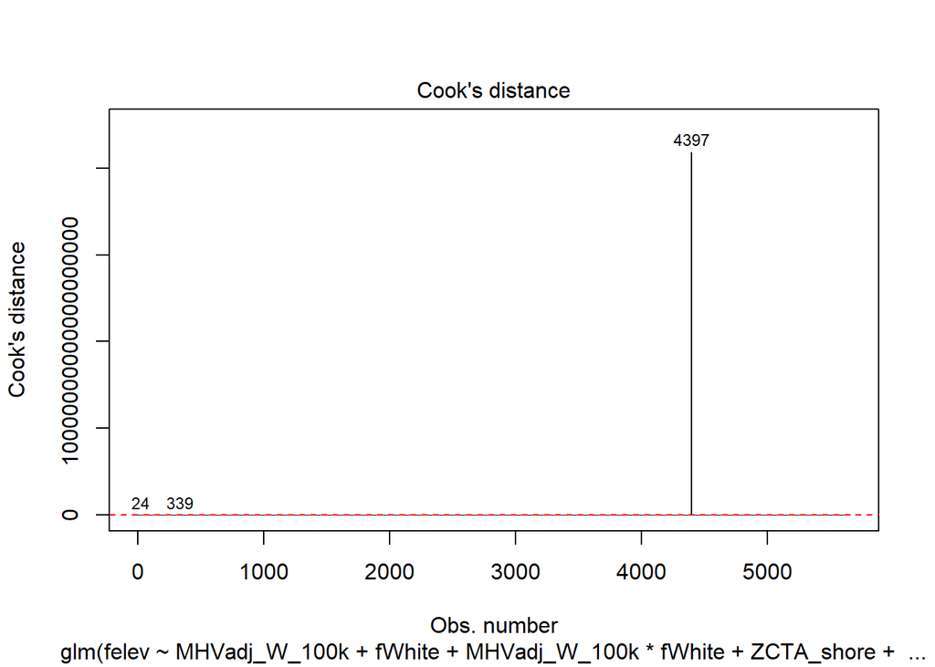

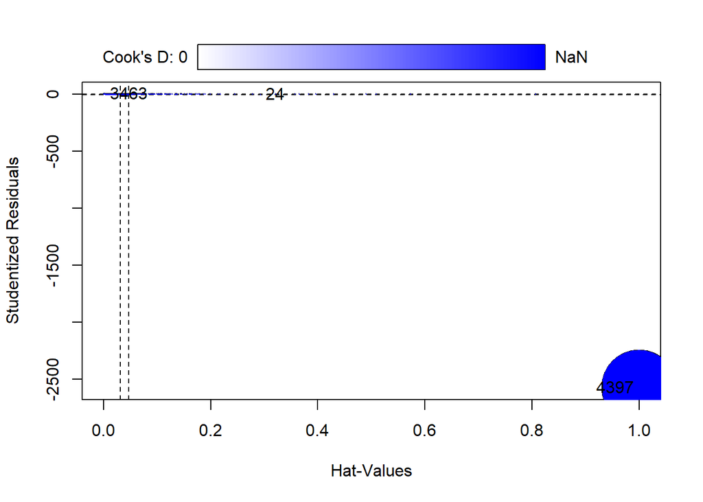

```
##           StudRes         Hat                         CookD
## 24      -1.956623 0.293336949                    0.01845292
## 1025          NaN 1.000000000                           NaN
## 3463     3.726420 0.002033153                    0.01319971
## 4397 -2572.151765 1.000000000 20923915851345616896.00000000
```

### 0.2.1 M1_Unlev: Dropping leverage points and rerunning model

**Logit Model Comparison: Dropping Influential Observations**

|  | *Dependent variable:* |
| --- | --- |
|  | Odds Ratio of felev |
| MHV (100k W) | 0.83 |
|  | (0.19) |
| Fraction White | 1.00 |
|  | (0.39) |
| Shoreline ZCTA | 4.73*** |
|  | (0.11) |
| Count of HUs in FEMA SFHA 1k (W) | 1.19*** |
|  | (0.03) |
| NFIP ICC Claims 1M (W) by ZCTA-YOL | 1.48*** |
|  | (0.12) |
| Population Density 1k (W) | 0.95 |
|  | (0.03) |
| MHV:Fraction White interaction | 1.61** |
|  | (0.22) |
| Constant | 0.00 |
|  | (5,774.69) |
| State FE | Yes |
| Year FE | Yes |
| Pseudo R2 | 0.48 |
| Observations | 5,654 |
| Log Likelihood | -1,602.83 |
| Akaike Inf. Crit. | 3,381.65 |
| *Note:* | p<0.1; p<0.05; p<0.01 |

##### 0.2.1.0.1 Post Tests M1_unLev

##### 0.2.1.0.2 Examining outliers and leverage points

###### 0.2.1.0.2.1 Diagnostics

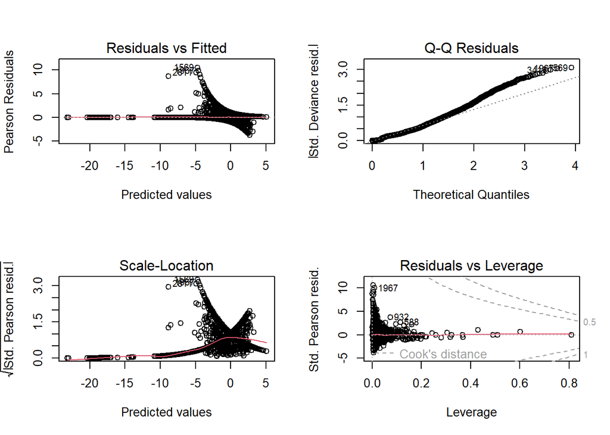

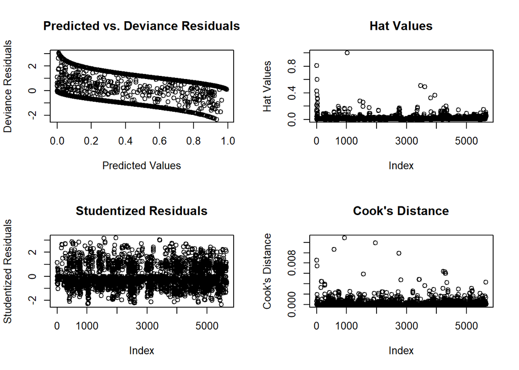

```
## No Studentized residuals with Bonferroni p < 0.05
## Largest |rstudent|:
##      rstudent unadjusted p-value Bonferroni p
## 1967 3.197115          0.0013881           NA
```

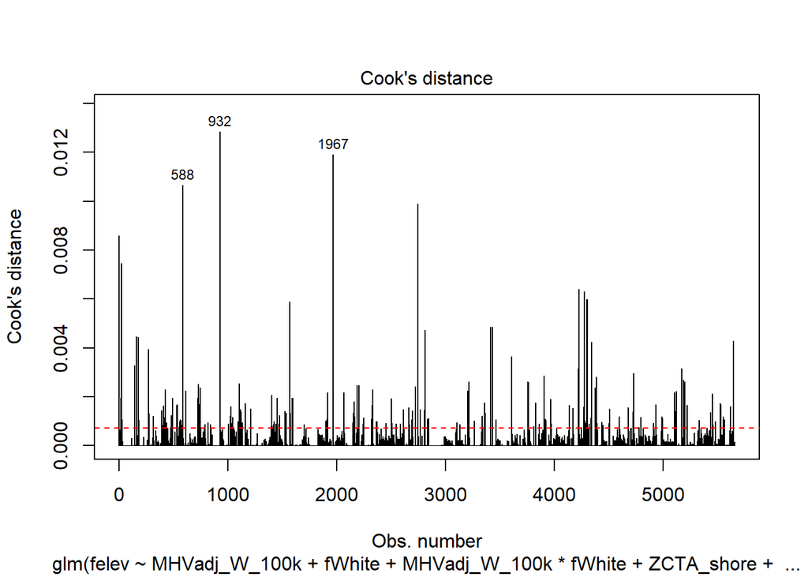

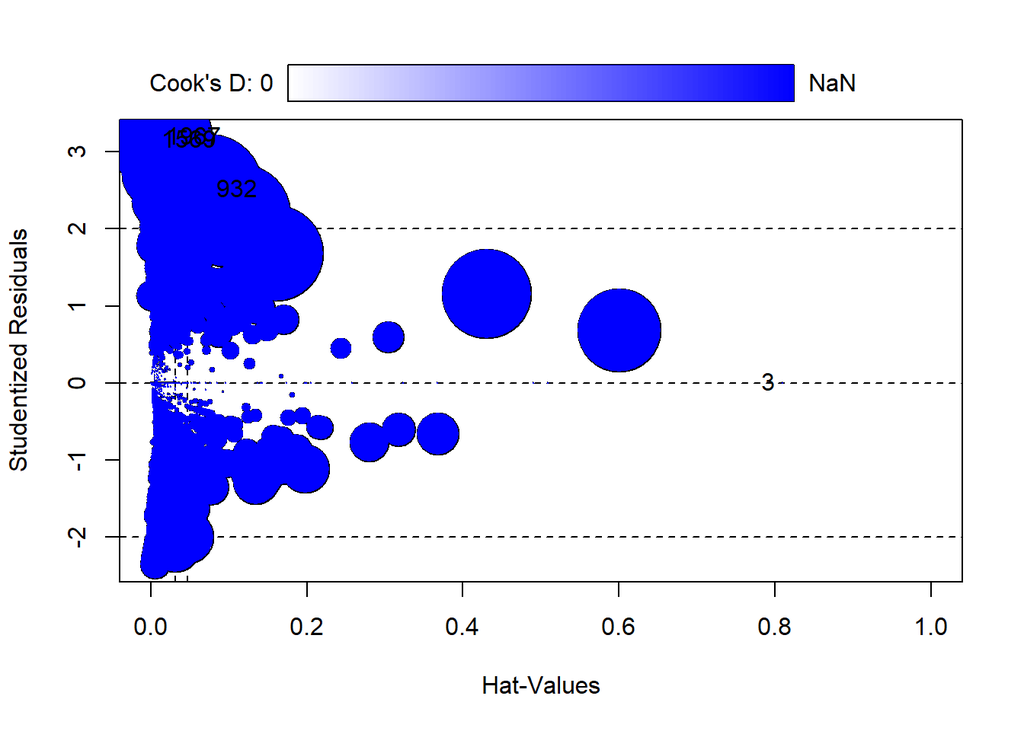

```
##            StudRes         Hat             CookD
## 3    -0.0003925317 0.809475405 0.000000006248575
## 932   2.5163934790 0.074308470 0.012857225418857
## 1025           NaN 1.000000000               NaN
## 1569  3.1540786364 0.004642516 0.005895281582554
## 1967  3.1971149329 0.010519282 0.011923350255961
```

###### 0.2.1.0.2.2 Drawing predicted probabilities

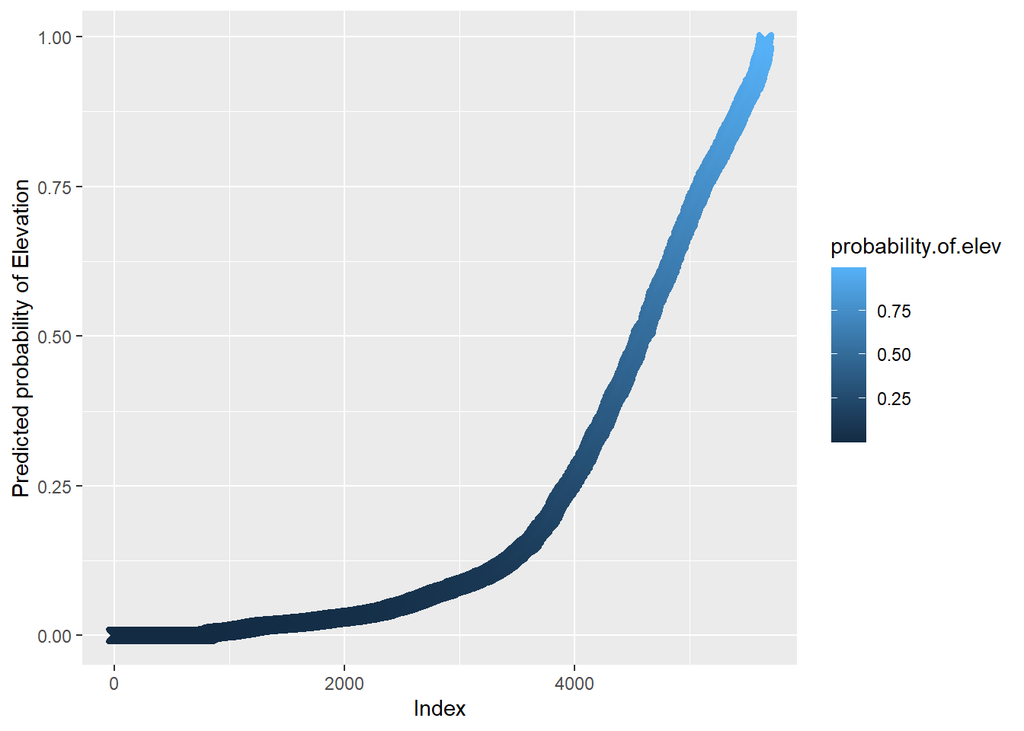

##### 0.2.1.0.3 Cross validation

###### 0.2.1.0.3.1 Confusion Matrix

```
## Confusion Matrix and Statistics
##
##           Reference
## Prediction Acqui Elev
##      Acqui   801   66
##      Elev     39  148
##
##                Accuracy : 0.9004
##                  95% CI : (0.8807, 0.9178)
##     No Information Rate : 0.797
##     P-Value [Acc > NIR] : < 0.0000000000000002
##
##                   Kappa : 0.677
##
##  Mcnemar's Test P-Value : 0.01117
##
##             Sensitivity : 0.9536
##             Specificity : 0.6916
##          Pos Pred Value : 0.9239
##          Neg Pred Value : 0.7914
##              Prevalence : 0.7970
##          Detection Rate : 0.7600
##    Detection Prevalence : 0.8226
##       Balanced Accuracy : 0.8226
##
##        'Positive' Class : Acqui
##
```

Note: working with reduced dataset where I have removed 4 outliers from here on out

## 0.3 Subsets / Robustness checks

Here we use the dataset where we have removed the outliers, and apply the same model to a series of subsets of interest as a robustness check

### 0.3.1 ZCTA_Shore Subset:

##### 0.3.1.0.1 M1_shore: Applying M1 model to Shore subset

**Logit Model 1: Shoreline Sample**

|  | *Dependent variable:* |
| --- | --- |
|  | odds Ratio of felev |
| MHV (100k W) | 0.91 |
|  | (0.29) |
| Fraction White | 2.89* |
|  | (0.60) |
| Count of HUs in FEMA SFHA 1k (W) | 1.17*** |
|  | (0.04) |
| NFIP ICC Claims 1M (W) by ZCTA-YOL | 1.43** |
|  | (0.14) |
| Population Density 1k (W) | 1.03 |
|  | (0.05) |
| MHV:Fraction White interaction | 1.33 |
|  | (0.32) |
| Constant | 10,898,380.00 |
|  | (2,399.54) |
| State FE | YES |
| Year FE | YES |
| Pseudo R2 | 0.31 |
| Observations | 1,321 |
| Log Likelihood | -629.91 |
| Akaike Inf. Crit. | 1,379.82 |
| *Note:* | p<0.1; p<0.05; p<0.01 |

##### 0.3.1.0.2 M1 Series A.0: Single variable model with FE for all explanatory vars:

**Logit Model Comparison: Single Variable Mode**

|  | *Dependent variable:* |  |  |  |  |  |  |
| --- | --- | --- | --- | --- | --- | --- | --- |
|  | odds Ratio of felev |  |  |  |  |  |  |
|  | (1) | (2) | (3) | (4) | (5) | (6) | (7) |
| MHV (100k W) |  | 1.35*** |  |  |  |  | 1.08 |
|  |  | (0.08) |  |  |  |  | (0.27) |
| Fraction White |  |  | 5.03*** |  |  |  | 2.96* |
|  |  |  | (0.35) |  |  |  | (0.58) |
| Count of HUs in FEMA SFHA 1k (W) |  |  |  | 1.21*** |  |  |  |
|  |  |  |  | (0.04) |  |  |  |
| NFIP ICC Claims 1M (W) by ZCTA-YOL |  |  |  |  | 1.58*** |  |  |
|  |  |  |  |  | (0.14) |  |  |
| Population Density 1k (W) |  |  |  |  |  | 0.99 |  |
|  |  |  |  |  |  | (0.04) |  |
| MHV:Fraction White interaction |  |  |  |  |  |  | 1.18 |
|  |  |  |  |  |  |  | (0.31) |
| Constant | 78,280,059.00 | 38,496,924.00 | 14,411,539.00 | 54,277,907.00 | 74,254,350.00 | 78,935,374.00 | 13,999,534.00 |
|  | (2,399.55) | (2,399.54) | (2,399.55) | (2,399.54) | (2,399.54) | (2,399.54) | (2,399.54) |
| State FE | YES | YES | YES | YES | YES | YES | YES |
| Year FE | YES | YES | YES | YES | YES | YES | YES |
| Pseudo R2 | 0.27 | 0.28 | 0.28 | 0.29 | 0.28 | 0.27 | 0.29 |
| Observations | 1,321 | 1,321 | 1,321 | 1,321 | 1,321 | 1,321 | 1,321 |
| Log Likelihood | -660.54 | -653.73 | -648.69 | -645.73 | -654.51 | -660.49 | -645.80 |
| Akaike Inf. Crit. | 1,429.09 | 1,417.46 | 1,407.38 | 1,401.45 | 1,419.03 | 1,430.97 | 1,405.59 |
| *Note:* | p<0.1; p<0.05; p<0.01 |  |  |  |  |  |  |

##### 0.3.1.0.3 M1 Series A.1 (Starting with best model from above and dropping vars)

**Logit Model Comparison: Shore Sample, Dropping variables**

|  | *Dependent variable:* |  |  |  |  |  |  |
| --- | --- | --- | --- | --- | --- | --- | --- |
|  | Odds Ratio of felev |  |  |  |  |  |  |
|  | (1) | (2) | (3) | (4) | (5) | (6) | (7) |
| MHV (100k W) | 0.91 | 0.91 | 0.91 | 1.17* | 0.97 | 0.92 | 0.96 |
|  | (0.29) | (0.29) | (0.29) | (0.08) | (0.28) | (0.29) | (0.28) |
| Fraction White | 2.89* | 2.89* | 2.89* | 4.26*** | 3.20** | 2.86* | 2.76* |
|  | (0.60) | (0.60) | (0.60) | (0.41) | (0.59) | (0.59) | (0.59) |
| Count of HUs in FEMA SFHA 1k (W) | 1.17*** | 1.17*** | 1.17*** | 1.17*** |  | 1.19*** | 1.17*** |
|  | (0.04) | (0.04) | (0.04) | (0.04) |  | (0.04) | (0.04) |
| NFIP ICC Claims 1M (W) by ZCTA-YOL | 1.43** | 1.43** | 1.43** | 1.43** | 1.57*** |  | 1.44*** |
|  | (0.14) | (0.14) | (0.14) | (0.14) | (0.14) |  | (0.14) |
| Population Density 1k (W) | 1.03 | 1.03 | 1.03 | 1.02 | 1.04 | 1.05 |  |
|  | (0.05) | (0.05) | (0.05) | (0.05) | (0.05) | (0.05) |  |
| MHV:Fraction White interaction | 1.33 |  | 1.33 |  | 1.29 | 1.32 | 1.27 |
|  | (0.32) |  | (0.32) |  | (0.31) | (0.32) | (0.31) |
| fWhite:MHVadj_W_100k |  | 1.33 |  |  |  |  |  |
|  |  | (0.32) |  |  |  |  |  |
| Constant | 10,898,380.00 | 10,898,384.00 | 10,898,380.00 | 8,168,058.00 | 12,060,921.00 | 11,024,854.00 | 11,786,000.00 |
|  | (2,399.54) | (2,399.55) | (2,399.54) | (2,399.54) | (2,399.54) | (2,399.55) | (2,399.55) |
| State FE | YES | YES | YES | YES | YES | YES | YES |
| Year FE | YES | YES | YES | YES | YES | YES | YES |
| Pseudo R2 | 0.31 | 0.31 | 0.31 | 0.31 | 0.3 | 0.3 | 0.31 |
| Observations | 1,321 | 1,321 | 1,321 | 1,321 | 1,321 | 1,321 | 1,321 |
| Log Likelihood | -629.91 | -629.91 | -629.91 | -630.12 | -639.49 | -633.56 | -629.95 |
| Akaike Inf. Crit. | 1,379.82 | 1,379.82 | 1,379.82 | 1,378.24 | 1,396.99 | 1,385.11 | 1,377.90 |
| *Note:* | p<0.1; p<0.05; p<0.01 |  |  |  |  |  |  |

Note that in this series, the model without the interaction term on fraction White and MHV (M4) has a lower AIC. The model with the lowest AIC is the one without population density.

### 0.3.2 Less “Mix” sample

Here we drop DNZs with a mix of elevations and buyouts

##### 0.3.2.0.1 M1_lessMix: Applying M1 model to ‘less Mix’ subset

**Logit Comparison: Less Mix Sample**

|  | *Dependent variable:* |
| --- | --- |
|  | odds Ratio of felev |
| MHV (100k W) | 0.82 |
|  | (0.21) |
| Fraction White | 1.22 |
|  | (0.45) |
| Shoreline ZCTA | 6.45*** |
|  | (0.12) |
| Count of HUs in FEMA SFHA 1k (W) | 1.22*** |
|  | (0.03) |
| NFIP ICC Claims 1M (W) by ZCTA-YOL | 1.78*** |
|  | (0.16) |
| Population Density 1k (W) | 0.93* |
|  | (0.04) |
| MHV:Fraction White interaction | 1.63** |
|  | (0.25) |
| Constant | 0.00 |
|  | (9,524.73) |
| State FE | YES |
| Year FE | YES |
| Pseudo R2 | 0.51 |
| Observations | 5,271 |
| Log Likelihood | -1,308.50 |
| Akaike Inf. Crit. | 2,792.99 |
| *Note:* | p<0.1; p<0.05; p<0.01 |

##### 0.3.2.0.2 M1 Series A.0: Single variable model with FE for all explanatory vars:

**Logit Model Comparison: Single Variable Mode**

|  | *Dependent variable:* |  |  |  |  |  |  |  |
| --- | --- | --- | --- | --- | --- | --- | --- | --- |
|  | odds Ratio of felev |  |  |  |  |  |  |  |
|  | (1) | (2) | (3) | (4) | (5) | (6) | (7) | (8) |
| MHV (100k W) |  | 1.49*** |  |  |  |  |  | 0.98 |
|  |  | (0.05) |  |  |  |  |  | (0.18) |
| Fraction White |  |  | 4.07*** |  |  |  |  | 1.43 |
|  |  |  | (0.24) |  |  |  |  | (0.40) |
| Shoreline ZCTA |  |  |  | 9.01*** |  |  |  |  |
|  |  |  |  | (0.11) |  |  |  |  |
| Count of HUs in FEMA SFHA 1k (W) |  |  |  |  | 1.51*** |  |  |  |
|  |  |  |  |  | (0.03) |  |  |  |
| NFIP ICC Claims 1M (W) by ZCTA-YOL |  |  |  |  |  | 3.14*** |  |  |
|  |  |  |  |  |  | (0.17) |  |  |
| Population Density 1k (W) |  |  |  |  |  |  | 1.00 |  |
|  |  |  |  |  |  |  | (0.03) |  |
| MHV:Fraction White interaction |  |  |  |  |  |  |  | 1.60** |
|  |  |  |  |  |  |  |  | (0.21) |
| Constant | 0.00 | 0.00 | 0.00 | 0.00 | 0.00 | 0.00 | 0.00 | 0.00 |
|  | (5,682.08) | (5,632.18) | (5,634.72) | (9,588.93) | (5,732.16) | (5,692.15) | (5,682.03) | (5,602.82) |
| State FE | YES | YES | YES | YES | YES | YES | YES |  |
| Year FE | YES | YES | YES | YES | YES | YES | YES |  |
| Pseudo R2 | 0.4 | 0.42 | 0.41 | 0.48 | 0.44 | 0.42 | 0.4 | 0.42 |
| Observations | 5,271 | 5,271 | 5,271 | 5,271 | 5,271 | 5,271 | 5,271 | 5,271 |
| Log Likelihood | -1,577.66 | -1,538.18 | -1,559.30 | -1,364.62 | -1,480.24 | -1,546.20 | -1,577.65 | -1,525.89 |
| Akaike Inf. Crit. | 3,317.32 | 3,240.35 | 3,282.59 | 2,893.24 | 3,124.47 | 3,256.41 | 3,319.30 | 3,219.79 |
| *Note:* | p<0.1; p<0.05; p<0.01 |  |  |  |  |  |  |  |

##### 0.3.2.0.3 M1 Series A.1 (Starting with best model from above and dropping vars)

**Logit Model Comparison: Full Sample, Dropping variables: Less Mix Sample**

|  | *Dependent variable:* |  |  |  |  |  |  |  |
| --- | --- | --- | --- | --- | --- | --- | --- | --- |
|  | Odds Ratio of felev |  |  |  |  |  |  |  |
|  | (1) | (2) | (3) | (4) | (5) | (6) | (7) | (8) |
| MHV (100k W) | 0.82 | 0.82 | 0.82 | 1.23*** | 0.94 | 0.84 | 0.82 | 0.73 |
|  | (0.21) | (0.21) | (0.21) | (0.05) | (0.21) | (0.21) | (0.21) | (0.20) |
| Fraction White | 1.22 | 1.22 | 1.22 | 2.37*** | 1.32 | 1.38 | 1.24 | 1.33 |
|  | (0.45) | (0.45) | (0.45) | (0.30) | (0.42) | (0.45) | (0.44) | (0.44) |
| Shoreline ZCTA | 6.45*** | 6.45*** | 6.45*** | 6.44*** |  | 7.82*** | 6.68*** | 6.39*** |
|  | (0.12) | (0.12) | (0.12) | (0.12) |  | (0.12) | (0.12) | (0.12) |
| Count of HUs in FEMA SFHA 1k (W) | 1.22*** | 1.22*** | 1.22*** | 1.22*** | 1.42*** |  | 1.24*** | 1.21*** |
|  | (0.03) | (0.03) | (0.03) | (0.03) | (0.03) |  | (0.03) | (0.03) |
| NFIP ICC Claims 1M (W) by ZCTA-YOL | 1.78*** | 1.78*** | 1.78*** | 1.77*** | 2.16*** | 2.10*** |  | 1.73*** |
|  | (0.16) | (0.16) | (0.16) | (0.15) | (0.15) | (0.16) |  | (0.16) |
| Population Density 1k (W) | 0.93* | 0.93* | 0.93* | 0.92** | 0.96 | 0.94 | 0.95 |  |
|  | (0.04) | (0.04) | (0.04) | (0.04) | (0.04) | (0.04) | (0.04) |  |
| MHV:Fraction White interaction | 1.63** |  | 1.63** |  | 1.55* | 1.61** | 1.61* | 1.80** |
|  | (0.25) |  | (0.25) |  | (0.24) | (0.24) | (0.24) | (0.24) |
| fWhite:MHVadj_W_100k |  | 1.63** |  |  |  |  |  |  |
|  |  | (0.25) |  |  |  |  |  |  |
| Constant | 0.00 | 0.00 | 0.00 | 0.00 | 0.00 | 0.00 | 0.00 | 0.00 |
|  | (9,524.73) | (9,524.73) | (9,524.73) | (9,530.52) | (5,668.79) | (9,501.04) | (9,524.85) | (9,515.03) |
| State FE | YES | YES | YES | YES | YES | YES | YES | YES |
| Year FE | YES | YES | YES | YES | YES | YES | YES | YES |
| Pseudo R2 | 0.51 | 0.51 | 0.51 | 0.5 | 0.46 | 0.5 | 0.5 | 0.5 |
| Observations | 5,271 | 5,271 | 5,271 | 5,271 | 5,271 | 5,271 | 5,271 | 5,271 |
| Log Likelihood | -1,308.50 | -1,308.50 | -1,308.50 | -1,310.46 | -1,432.06 | -1,325.57 | -1,316.27 | -1,310.13 |
| Akaike Inf. Crit. | 2,792.99 | 2,792.99 | 2,792.99 | 2,794.92 | 3,038.13 | 2,825.15 | 2,806.55 | 2,794.27 |
| *Note:* | p<0.1; p<0.05; p<0.01 |  |  |  |  |  |  |  |

### 0.3.3 After 1993 sample

Here we drop DNZs that occured before 1993, give that the majority of buyouts occured in the great midwest flood of 1993

##### 0.3.3.0.1 M1 After 1993: Applying M1 model to DNZs after 1993

**Logit Comparison: After 1993 Sample**

|  | *Dependent variable:* |
| --- | --- |
|  | odds Ratio of felev |
| MHV (100k W) | 0.84 |
|  | (0.19) |
| Fraction White | 1.03 |
|  | (0.39) |
| Shoreline ZCTA | 4.69*** |
|  | (0.11) |
| Count of HUs in FEMA SFHA 1k (W) | 1.19*** |
|  | (0.03) |
| NFIP ICC Claims 1M (W) by ZCTA-YOL | 1.49*** |
|  | (0.12) |
| Population Density 1k (W) | 0.94* |
|  | (0.03) |
| MHV:Fraction White interaction | 1.58** |
|  | (0.22) |
| Constant | 0.00 |
|  | (4,612.02) |
| State FE | YES |
| Year FE | YES |
| Pseudo R2 | 0.47 |
| Observations | 5,391 |
| Log Likelihood | -1,583.77 |
| Akaike Inf. Crit. | 3,333.54 |
| *Note:* | p<0.1; p<0.05; p<0.01 |

##### 0.3.3.0.2 M1 Series A.0: Single variable model with FE for all explanatory vars:

**Logit Model Comparison: Single Variable Mode**

|  | *Dependent variable:* |  |  |  |  |  |  |  |
| --- | --- | --- | --- | --- | --- | --- | --- | --- |
|  | odds Ratio of felev |  |  |  |  |  |  |  |
|  | (1) | (2) | (3) | (4) | (5) | (6) | (7) | (8) |
| MHV (100k W) |  | 1.43*** |  |  |  |  |  | 0.95 |
|  |  | (0.04) |  |  |  |  |  | (0.17) |
| Fraction White |  |  | 3.52*** |  |  |  |  | 1.31 |
|  |  |  | (0.21) |  |  |  |  | (0.36) |
| Shoreline ZCTA |  |  |  | 6.41*** |  |  |  |  |
|  |  |  |  | (0.10) |  |  |  |  |
| Count of HUs in FEMA SFHA 1k (W) |  |  |  |  | 1.42*** |  |  |  |
|  |  |  |  |  | (0.03) |  |  |  |
| NFIP ICC Claims 1M (W) by ZCTA-YOL |  |  |  |  |  | 2.32*** |  |  |
|  |  |  |  |  |  | (0.12) |  |  |
| Population Density 1k (W) |  |  |  |  |  |  | 0.99 |  |
|  |  |  |  |  |  |  | (0.03) |  |
| MHV:Fraction White interaction |  |  |  |  |  |  |  | 1.59** |
|  |  |  |  |  |  |  |  | (0.20) |
| Constant | 0.00 | 0.00 | 0.00 | 0.00 | 0.00 | 0.00 | 0.00 | 0.00 |
|  | (4,612.20) | (4,600.21) | (4,611.79) | (4,612.21) | (4,612.10) | (4,612.20) | (4,612.19) | (4,606.27) |
| State FE | YES | YES | YES | YES | YES | YES | YES |  |
| Year FE | YES | YES | YES | YES | YES | YES | YES |  |
| Pseudo R2 | 0.38 | 0.39 | 0.39 | 0.45 | 0.41 | 0.39 | 0.38 | 0.4 |
| Observations | 5,391 | 5,391 | 5,391 | 5,391 | 5,391 | 5,391 | 5,391 | 5,391 |
| Log Likelihood | -1,839.65 | -1,803.01 | -1,820.78 | -1,637.93 | -1,744.29 | -1,810.01 | -1,839.64 | -1,790.55 |
| Akaike Inf. Crit. | 3,831.29 | 3,760.03 | 3,795.56 | 3,429.86 | 3,642.58 | 3,774.02 | 3,833.28 | 3,739.10 |
| *Note:* | p<0.1; p<0.05; p<0.01 |  |  |  |  |  |  |  |

##### 0.3.3.0.3 M1 Series A.1 (Starting with best model from above and dropping vars)

**Logit Model Comparison: Dropping variables: After 1993 Sample**

|  | *Dependent variable:* |  |  |  |  |  |  |  |
| --- | --- | --- | --- | --- | --- | --- | --- | --- |
|  | Odds Ratio of felev |  |  |  |  |  |  |  |
|  | (1) | (2) | (3) | (4) | (5) | (6) | (7) | (8) |
| MHV (100k W) | 0.84 | 0.84 | 0.84 | 1.23*** | 0.92 | 0.85 | 0.85 | 0.76 |
|  | (0.19) | (0.19) | (0.19) | (0.05) | (0.19) | (0.19) | (0.19) | (0.18) |
| Fraction White | 1.03 | 1.03 | 1.03 | 1.87** | 1.14 | 1.13 | 1.08 | 1.11 |
|  | (0.39) | (0.39) | (0.39) | (0.27) | (0.38) | (0.39) | (0.39) | (0.39) |
| Shoreline ZCTA | 4.69*** | 4.69*** | 4.69*** | 4.69*** |  | 5.55*** | 4.87*** | 4.66*** |
|  | (0.11) | (0.11) | (0.11) | (0.11) |  | (0.10) | (0.11) | (0.11) |
| Count of HUs in FEMA SFHA 1k (W) | 1.19*** | 1.19*** | 1.19*** | 1.19*** | 1.34*** |  | 1.21*** | 1.18*** |
|  | (0.03) | (0.03) | (0.03) | (0.03) | (0.03) |  | (0.03) | (0.03) |
| NFIP ICC Claims 1M (W) by ZCTA-YOL | 1.49*** | 1.49*** | 1.49*** | 1.48*** | 1.78*** | 1.67*** |  | 1.45*** |
|  | (0.12) | (0.12) | (0.12) | (0.12) | (0.12) | (0.12) |  | (0.12) |
| Population Density 1k (W) | 0.94* | 0.94* | 0.94* | 0.93** | 0.96 | 0.95 | 0.96 |  |
|  | (0.03) | (0.03) | (0.03) | (0.03) | (0.03) | (0.03) | (0.03) |  |
| MHV:Fraction White interaction | 1.58** |  | 1.58** |  | 1.55** | 1.59** | 1.55** | 1.72** |
|  | (0.22) |  | (0.22) |  | (0.22) | (0.22) | (0.22) | (0.22) |
| fWhite:MHVadj_W_100k |  | 1.58** |  |  |  |  |  |  |
|  |  | (0.22) |  |  |  |  |  |  |
| Constant | 0.00 | 0.00 | 0.00 | 0.00 | 0.00 | 0.00 | 0.00 | 0.00 |
|  | (4,612.02) | (4,612.02) | (4,612.02) | (4,611.97) | (4,609.87) | (4,611.93) | (4,611.81) | (4,610.97) |
| State FE | YES | YES | YES | YES | YES | YES | YES | YES |
| Year FE | YES | YES | YES | YES | YES | YES | YES | YES |
| Pseudo R2 | 0.47 | 0.47 | 0.47 | 0.47 | 0.43 | 0.46 | 0.47 | 0.47 |
| Observations | 5,391 | 5,391 | 5,391 | 5,391 | 5,391 | 5,391 | 5,391 | 5,391 |
| Log Likelihood | -1,583.77 | -1,583.77 | -1,583.77 | -1,585.41 | -1,698.97 | -1,603.16 | -1,589.91 | -1,585.17 |
| Akaike Inf. Crit. | 3,333.54 | 3,333.54 | 3,333.54 | 3,334.82 | 3,561.95 | 3,370.32 | 3,343.81 | 3,334.34 |
| *Note:* | p<0.1; p<0.05; p<0.01 |  |  |  |  |  |  |  |

### 0.3.4 Without Sandy Sample

Here we drop Sandy, given that this storm drove the majority of elevations and buyouts

##### 0.3.4.0.1 M1 without Sandy: Applying M1 model to all DNZs except Sandy

**Logit Comparison: Without Sandy Sample**

[output not shown]

##### 0.3.4.0.2 M1 Series A.0: Single variable model with FE for all explanatory vars:

**Logit Model Comparison: Single Variable Mode**

|  | *Dependent variable:* |  |  |  |  |  |  |  |
| --- | --- | --- | --- | --- | --- | --- | --- | --- |
|  | odds Ratio of felev |  |  |  |  |  |  |  |
|  | (1) | (2) | (3) | (4) | (5) | (6) | (7) | (8) |
| MHV (100k W) |  | 1.48*** |  |  |  |  |  | 1.06 |
|  |  | (0.05) |  |  |  |  |  | (0.18) |
| Fraction White |  |  | 3.23*** |  |  |  |  | 1.40 |
|  |  |  | (0.22) |  |  |  |  | (0.37) |
| Shoreline ZCTA |  |  |  | 6.37*** |  |  |  |  |
|  |  |  |  | (0.10) |  |  |  |  |
| Count of HUs in FEMA SFHA 1k (W) |  |  |  |  | 1.42*** |  |  |  |
|  |  |  |  |  | (0.03) |  |  |  |
| NFIP ICC Claims 1M (W) by ZCTA-YOL |  |  |  |  |  | 2.33*** |  |  |
|  |  |  |  |  |  | (0.12) |  |  |
| Population Density 1k (W) |  |  |  |  |  |  | 1.02 |  |
|  |  |  |  |  |  |  | (0.03) |  |
| MHV:Fraction White interaction |  |  |  |  |  |  |  | 1.45* |
|  |  |  |  |  |  |  |  | (0.21) |
| Constant | 0.00 | 0.00 | 0.00 | 0.00 | 0.00 | 0.00 | 0.00 | 0.00 |
|  | (3,456.36) | (5,645.30) | (5,655.92) | (5,814.16) | (5,743.32) | (5,709.36) | (3,456.36) | (5,618.72) |
| State FE | YES | YES | YES | YES | YES | YES | YES |  |
| Year FE | YES | YES | YES | YES | YES | YES | YES |  |
| Pseudo R2 | 0.38 | 0.4 | 0.39 | 0.45 | 0.41 | 0.39 | 0.38 | 0.4 |
| Observations | 5,509 | 5,509 | 5,509 | 5,509 | 5,509 | 5,509 | 5,509 | 5,509 |
| Log Likelihood | -1,790.92 | -1,752.01 | -1,775.07 | -1,598.27 | -1,700.01 | -1,760.97 | -1,790.61 | -1,742.82 |
| Akaike Inf. Crit. | 3,743.84 | 3,668.02 | 3,714.13 | 3,360.54 | 3,564.02 | 3,685.94 | 3,745.23 | 3,653.64 |
| *Note:* | p<0.1; p<0.05; p<0.01 |  |  |  |  |  |  |  |

##### 0.3.4.0.3 M1 Series A.1 (Starting with best model from above and dropping vars)

**Logit Model Comparison: Dropping variables: Without Sandy Sample**

|  | *Dependent variable:* |  |  |  |  |  |  |  |
| --- | --- | --- | --- | --- | --- | --- | --- | --- |
|  | Odds Ratio of felev |  |  |  |  |  |  |  |
|  | (1) | (2) | (3) | (4) | (5) | (6) | (7) | (8) |
| MHV (100k W) | 0.92 | 0.92 | 0.92 | 1.25*** | 0.99 | 0.94 | 0.94 | 0.86 |
|  | (0.20) | (0.20) | (0.20) | (0.05) | (0.20) | (0.20) | (0.20) | (0.19) |
| Fraction White | 1.15 | 1.15 | 1.15 | 1.83** | 1.24 | 1.27 | 1.21 | 1.22 |
|  | (0.40) | (0.40) | (0.40) | (0.27) | (0.39) | (0.40) | (0.40) | (0.40) |
| Shoreline ZCTA | 4.59*** | 4.59*** | 4.59*** | 4.60*** |  | 5.43*** | 4.77*** | 4.57*** |
|  | (0.11) | (0.11) | (0.11) | (0.11) |  | (0.10) | (0.11) | (0.11) |
| Count of HUs in FEMA SFHA 1k (W) | 1.18*** | 1.18*** | 1.18*** | 1.18*** | 1.34*** |  | 1.20*** | 1.18*** |
|  | (0.03) | (0.03) | (0.03) | (0.03) | (0.03) |  | (0.03) | (0.03) |
| NFIP ICC Claims 1M (W) by ZCTA-YOL | 1.49*** | 1.49*** | 1.49*** | 1.48*** | 1.77*** | 1.67*** |  | 1.47*** |
|  | (0.12) | (0.12) | (0.12) | (0.12) | (0.12) | (0.12) |  | (0.12) |
| Population Density 1k (W) | 0.96 | 0.96 | 0.96 | 0.95 | 0.98 | 0.97 | 0.97 |  |
|  | (0.04) | (0.04) | (0.04) | (0.04) | (0.04) | (0.04) | (0.04) |  |
| MHV:Fraction White interaction | 1.44 |  | 1.44 |  | 1.46 | 1.44 | 1.41 | 1.53* |
|  | (0.24) |  | (0.24) |  | (0.23) | (0.23) | (0.24) | (0.23) |
| fWhite:MHVadj_W_100k |  | 1.44 |  |  |  |  |  |  |
|  |  | (0.24) |  |  |  |  |  |  |
| Constant | 0.00 | 0.00 | 0.00 | 0.00 | 0.00 | 0.00 | 0.00 | 0.00 |
|  | (5,774.82) | (5,774.82) | (5,774.82) | (5,779.03) | (5,679.86) | (5,761.56) | (5,773.95) | (5,770.16) |
| State FE | YES | YES | YES | YES | YES | YES | YES | YES |
| Year FE | YES | YES | YES | YES | YES | YES | YES | YES |
| Pseudo R2 | 0.47 | 0.47 | 0.47 | 0.47 | 0.43 | 0.46 | 0.46 | 0.47 |
| Observations | 5,509 | 5,509 | 5,509 | 5,509 | 5,509 | 5,509 | 5,509 | 5,509 |
| Log Likelihood | -1,548.81 | -1,548.81 | -1,548.81 | -1,549.64 | -1,655.91 | -1,565.81 | -1,555.04 | -1,549.36 |
| Akaike Inf. Crit. | 3,273.62 | 3,273.62 | 3,273.62 | 3,273.28 | 3,485.83 | 3,305.61 | 3,284.07 | 3,272.72 |
| *Note:* | p<0.1; p<0.05; p<0.01 |  |  |  |  |  |  |  |

The AIC minimizing model does not include population density

## 0.4 Logistic Regression Models: 5 samples (X Series)

##### 0.4.0.0.1 Model Series X.1 (models by sample - all variables M1)

Here we jointly display the results for each sample

**Logit Models: All Samples, All Vars (M1)**

|  | *Dependent variable:* |  |  |  |  |
| --- | --- | --- | --- | --- | --- |
|  | Odds Ratio of felev |  |  |  |  |
|  | (1) | (2) | (3) | (4) | (5) |
| MHV (100k W) | 0.83 | 0.82 | 0.84 | 0.92 | 0.91 |
|  | (0.19) | (0.21) | (0.19) | (0.20) | (0.29) |
| Fraction White | 1.00 | 1.22 | 1.03 | 1.15 | 2.89* |
|  | (0.39) | (0.45) | (0.39) | (0.40) | (0.60) |
| Shoreline ZCTA | 4.73*** | 6.45*** | 4.69*** | 4.59*** |  |
|  | (0.11) | (0.12) | (0.11) | (0.11) |  |
| Count of HUs in FEMA SFHA 1k (W) | 1.19*** | 1.22*** | 1.19*** | 1.18*** | 1.17*** |
|  | (0.03) | (0.03) | (0.03) | (0.03) | (0.04) |
| NFIP ICC Claims 1M (W) by ZCTA-YOL | 1.48*** | 1.78*** | 1.49*** | 1.49*** | 1.43** |
|  | (0.12) | (0.16) | (0.12) | (0.12) | (0.14) |
| Population Density 1k (W) | 0.95 | 0.93* | 0.94* | 0.96 | 1.03 |
|  | (0.03) | (0.04) | (0.03) | (0.04) | (0.05) |
| MHV:Fraction White interaction | 1.61** | 1.63** | 1.58** | 1.44 | 1.33 |
|  | (0.22) | (0.25) | (0.22) | (0.24) | (0.32) |
| Constant | 0.00 | 0.00 | 0.00 | 0.00 | 10,898,380.00 |
|  | (5,774.69) | (9,524.73) | (4,612.02) | (5,774.82) | (2,399.54) |
| Sample | Full | Less Mix | After 1993 | w/o Sandy | Shore ZCTA |
| State FE | YES | YES | YES | YES | YES |
| Year FE | YES | YES | YES | YES | YES |
| Pseudo R2 | 0.48 | 0.51 | 0.47 | 0.47 | 0.31 |
| Observations | 5,654 | 5,271 | 5,391 | 5,509 | 1,321 |
| Log Likelihood | -1,602.83 | -1,308.50 | -1,583.77 | -1,548.81 | -629.91 |
| Akaike Inf. Crit. | 3,381.65 | 2,792.99 | 3,333.54 | 3,273.62 | 1,379.82 |
| *Note:* | p<0.1; p<0.05; p<0.01 |  |  |  |  |

Notice how the significance falls away on the interaction term when Sandy is taken out of the sample.

##### 0.4.0.0.2 Model Series X.2 (models by sample - AIC minimizing models M1)

Here we jointly display the results for each sample, with the AIC minizing model. The AIC minimizing model does for the “Without Sandy” and “Shoreline” samples do not include population density.

**Logit Models: All Samples, All Vars (M1)**

|  | *Dependent variable:* |  |  |  |  |
| --- | --- | --- | --- | --- | --- |
|  | Odds Ratio of felev |  |  |  |  |
|  | (1) | (2) | (3) | (4) | (5) |
| MHV (100k W) | 0.83 | 0.82 | 0.84 | 0.86 | 0.96 |
|  | (0.19) | (0.21) | (0.19) | (0.19) | (0.28) |
| Fraction White | 1.00 | 1.22 | 1.03 | 1.22 | 2.76* |
|  | (0.39) | (0.45) | (0.39) | (0.40) | (0.59) |
| Shoreline ZCTA | 4.73*** | 6.45*** | 4.69*** | 4.57*** |  |
|  | (0.11) | (0.12) | (0.11) | (0.11) |  |
| Count of HUs in FEMA SFHA 1k (W) | 1.19*** | 1.22*** | 1.19*** | 1.18*** | 1.17*** |
|  | (0.03) | (0.03) | (0.03) | (0.03) | (0.04) |
| NFIP ICC Claims 1M (W) by ZCTA-YOL | 1.48*** | 1.78*** | 1.49*** | 1.47*** | 1.44*** |
|  | (0.12) | (0.16) | (0.12) | (0.12) | (0.14) |
| Population Density 1k (W) | 0.95 | 0.93* | 0.94* |  |  |
|  | (0.03) | (0.04) | (0.03) |  |  |
| MHV:Fraction White interaction | 1.61** | 1.63** | 1.58** | 1.53* | 1.27 |
|  | (0.22) | (0.25) | (0.22) | (0.23) | (0.31) |
| Constant | 0.00 | 0.00 | 0.00 | 0.00 | 11,786,000.00 |
|  | (5,774.69) | (9,524.73) | (4,612.02) | (5,770.16) | (2,399.55) |
| Sample | Full | Less Mix | After 1993 | w/o Sandy | Shore ZCTA |
| State FE | YES | YES | YES | YES | YES |
| Year FE | YES | YES | YES | YES | YES |
| Pseudo R2 | 0.48 | 0.51 | 0.47 | 0.47 | 0.31 |
| Observations | 5,654 | 5,271 | 5,391 | 5,509 | 1,321 |
| Log Likelihood | -1,602.83 | -1,308.50 | -1,583.77 | -1,549.36 | -629.95 |
| Akaike Inf. Crit. | 3,381.65 | 2,792.99 | 3,333.54 | 3,272.72 | 1,377.90 |
| *Note:* | p<0.1; p<0.05; p<0.01 |  |  |  |  |

##### 0.4.0.0.3 Model Series X.3 (models by sample: sensitivity: Subbing IHP for ICC)

Here we jointly display the results for each sample

**Logit Models: All Samples, All Vars (M1)**

|  | *Dependent variable:* |  |  |  |  |
| --- | --- | --- | --- | --- | --- |
|  | Odds Ratio of felev |  |  |  |  |
|  | (1) | (2) | (3) | (4) | (5) |
| MHV 100k (W) | 0.83 | 0.82 | 0.84 | 0.92 | 0.91 |
|  | (0.19) | (0.21) | (0.19) | (0.20) | (0.29) |
| Fraction White | 1.04 | 1.28 | 1.07 | 1.20 | 2.93* |
|  | (0.39) | (0.45) | (0.39) | (0.40) | (0.60) |
| Shoreline ZCTA | 4.87*** | 6.63*** | 4.83*** | 4.74*** |  |
|  | (0.11) | (0.12) | (0.11) | (0.11) |  |
| Count of HUs in FEMA SFHA 1k (W) | 1.19*** | 1.23*** | 1.19*** | 1.19*** | 1.18*** |
|  | (0.03) | (0.03) | (0.03) | (0.03) | (0.04) |
| IHP Flood Damages 10M (W) | 1.17*** | 1.18** | 1.17*** | 1.19*** | 1.15* |
|  | (0.06) | (0.08) | (0.06) | (0.06) | (0.08) |
| Population Density 1k (W) | 0.95 | 0.94 | 0.95 | 0.97 | 1.04 |
|  | (0.03) | (0.04) | (0.03) | (0.04) | (0.05) |
| MHV:Fraction White interaction | 1.60** | 1.61* | 1.56** | 1.43 | 1.33 |
|  | (0.22) | (0.25) | (0.22) | (0.24) | (0.32) |
| Constant | 0.00 | 0.00 | 0.00 | 0.00 | 11,124,938.00 |
|  | (5,772.09) | (9,521.71) | (4,611.98) | (5,772.17) | (2,399.55) |
| Sample | Full | Less Mix | After 1993 | w/o Sandy | Shore ZCTA |
| State FE | YES | YES | YES | YES | YES |
| Year FE | YES | YES | YES | YES | YES |
| Pseudo R2 | 0.47 | 0.5 | 0.47 | 0.47 | 0.31 |
| Observations | 5,654 | 5,271 | 5,391 | 5,509 | 1,321 |
| Log Likelihood | -1,605.44 | -1,313.67 | -1,586.44 | -1,551.27 | -631.92 |
| Akaike Inf. Crit. | 3,386.88 | 2,803.34 | 3,338.87 | 3,278.53 | 1,383.84 |
| *Note:* | p<0.1; p<0.05; p<0.01 |  |  |  |  |

Here we jointly display the results for each sample

**Logit Models: All Samples, All Vars (M1)**

|  | *Dependent variable:* |  |  |  |  |
| --- | --- | --- | --- | --- | --- |
|  | Odds Ratio of felev |  |  |  |  |
|  | (1) | (2) | (3) | (4) | (5) |
| MHV 100k (W) | 0.92 | 0.90 | 0.93 | 0.94 | 0.97 |
|  | (0.13) | (0.14) | (0.13) | (0.13) | (0.20) |
| Conservative Ideology | 0.57 | 0.49 | 0.63 | 0.72 | 8.22 |
|  | (0.85) | (0.94) | (0.85) | (0.86) | (1.29) |
| Shoreline ZCTA | 4.72*** | 6.35*** | 4.67*** | 4.55*** |  |
|  | (0.11) | (0.12) | (0.11) | (0.11) |  |
| Count of HUs in FEMA SFHA 1k (W) | 1.19*** | 1.23*** | 1.19*** | 1.19*** | 1.19*** |
|  | (0.03) | (0.03) | (0.03) | (0.03) | (0.04) |
| IHP Flood Damages 10M (W) | 1.17** | 1.18** | 1.17** | 1.19*** | 1.15* |
|  | (0.06) | (0.08) | (0.06) | (0.06) | (0.08) |
| Population Density 1k (W) | 0.93** | 0.91** | 0.93** | 0.96 | 1.04 |
|  | (0.03) | (0.04) | (0.03) | (0.04) | (0.05) |
| MHV:Fraction White interaction | 2.95*** | 3.38*** | 2.89*** | 2.96*** | 2.78* |
|  | (0.40) | (0.43) | (0.40) | (0.41) | (0.62) |
| Constant | 0.00 | 0.00 | 0.00 | 0.00 | 12,858,495.00 |
|  | (5,810.46) | (9,590.99) | (4,610.86) | (5,811.02) | (2,399.55) |
| Sample | Full | Less Mix | After 1993 | w/o Sandy | Shore ZCTA |
| State FE | YES | YES | YES | YES | YES |
| Year FE | YES | YES | YES | YES | YES |
| Pseudo R2 | 0.47 | 0.5 | 0.47 | 0.47 | 0.31 |
| Observations | 5,654 | 5,271 | 5,391 | 5,509 | 1,321 |
| Log Likelihood | -1,605.13 | -1,313.72 | -1,585.77 | -1,549.09 | -627.48 |
| Akaike Inf. Crit. | 3,386.26 | 2,803.44 | 3,337.54 | 3,274.18 | 1,374.95 |
| *Note:* | p<0.1; p<0.05; p<0.01 |  |  |  |  |